# Results:mini_project_1.sas

The FREQ Procedure

| city_development_index | city_development_index Frequency | city_development_index Percent | city_development_index Cumulative Frequency | city_development_index Cumulative Percent |
| --- | --- | --- | --- | --- |
| 0 | 6709 | 46.40 | 6709 | 46.40 |
| 1 | 7750 | 53.60 | 14459 | 100.00 |

| Chi-Square Test for Equal Proportions |  |
| --- | --- |
| Chi-Square | 74.9485 |
| DF | 1 |
| Pr > ChiSq | <.0001 |

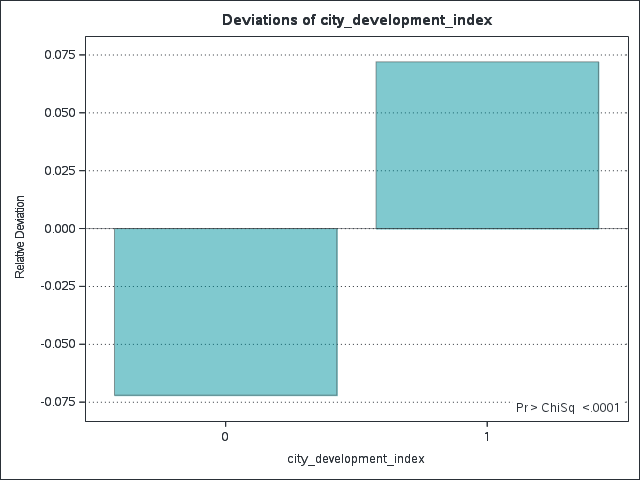

Sample Size = 14459

| gender | gender Frequency | gender Percent | gender Cumulative Frequency | gender Cumulative Percent |
| --- | --- | --- | --- | --- |
| 0 | 13221 | 91.44 | 13221 | 91.44 |
| 1 | 1238 | 8.56 | 14459 | 100.00 |

| Chi-Square Test for Equal Proportions |  |
| --- | --- |
| Chi-Square | 9930.9972 |
| DF | 1 |
| Pr > ChiSq | <.0001 |

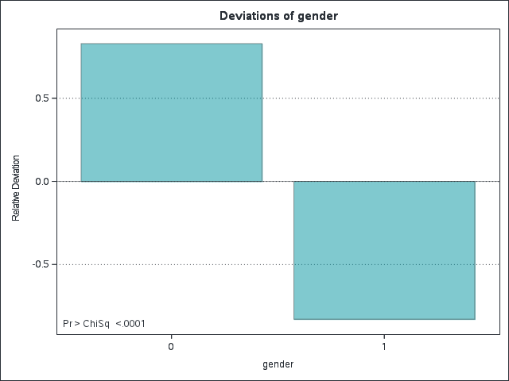

Sample Size = 14459

| education_level | education_level Frequency | education_level Percent | education_level Cumulative Frequency | education_level Cumulative Percent |
| --- | --- | --- | --- | --- |
| 0 | 1919 | 13.27 | 1919 | 13.27 |
| 1 | 12540 | 86.73 | 14459 | 100.00 |

| Chi-Square Test for Equal Proportions |  |
| --- | --- |
| Chi-Square | 7801.7595 |
| DF | 1 |
| Pr > ChiSq | <.0001 |

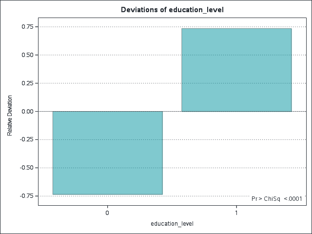

Sample Size = 14459

| target | Frequency | Percent | Cumulative Frequency | Cumulative Percent |
| --- | --- | --- | --- | --- |
| 0 | 11121 | 76.91 | 11121 | 76.91 |
| 1 | 3338 | 23.09 | 14459 | 100.00 |

| Chi-Square Test for Equal Proportions |  |
| --- | --- |
| Chi-Square | 4189.4383 |
| DF | 1 |
| Pr > ChiSq | <.0001 |

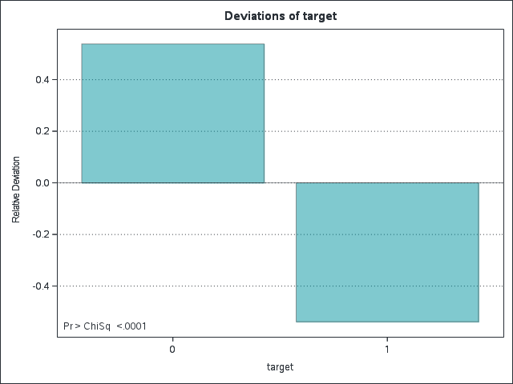

Sample Size = 14459

The FREQ Procedure

| Frequency Percent Row Pct Col Pct |
| --- |

| Table 1 of education_level by target Controlling for city_development_index=0 gender=0 education_level(education_level) | Table 1 of education_level by target Controlling for city_development_index=0 gender=0 target 0 | Table 1 of education_level by target Controlling for city_development_index=0 gender=0 target 1 | Table 1 of education_level by target Controlling for city_development_index=0 gender=0 target Total |
| --- | --- | --- | --- |
| 0 | 716 11.54 78.34 16.52 | 198 3.19 21.66 10.58 | 914 14.73 |
| 1 | 3619 58.31 68.37 83.48 | 1674 26.97 31.63 89.42 | 5293 85.27 |
| Total | 4335 69.84 | 1872 30.16 | 6207 100.00 |

Statistics for Table 1 of education_level by target  
Controlling for city_development_index=0 gender=0

| Statistic | DF | Value | Prob |
| --- | --- | --- | --- |
| Chi-Square | 1 | 36.7344 | <.0001 |
| Likelihood Ratio Chi-Square | 1 | 38.7290 | <.0001 |
| Continuity Adj. Chi-Square | 1 | 36.2629 | <.0001 |
| Mantel-Haenszel Chi-Square | 1 | 36.7284 | <.0001 |
| Phi Coefficient |  | 0.0769 |  |
| Contingency Coefficient |  | 0.0767 |  |
| Cramer's V |  | 0.0769 |  |

| Fisher's Exact Test |  |
| --- | --- |
| Cell (1,1) Frequency (F) | 716 |
| Left-sided Pr <= F | 1.0000 |
| Right-sided Pr >= F | <.0001 |
| Table Probability (P) | <.0001 |
| Two-sided Pr <= P | <.0001 |

| Statistic | Value | ASE |
| --- | --- | --- |
| Gamma | 0.2517 | 0.0401 |
| Kendall's Tau-b | 0.0769 | 0.0116 |
| Stuart's Tau-c | 0.0500 | 0.0077 |
| Somers' D C\|R | 0.0996 | 0.0151 |
| Somers' D R\|C | 0.0594 | 0.0091 |
| Pearson Correlation | 0.0769 | 0.0116 |
| Spearman Correlation | 0.0769 | 0.0116 |
| Lambda Asymmetric C\|R | 0.0000 | 0.0000 |
| Lambda Asymmetric R\|C | 0.0000 | 0.0000 |
| Lambda Symmetric | 0.0000 | 0.0000 |
| Uncertainty Coefficient C\|R | 0.0051 | 0.0016 |
| Uncertainty Coefficient R\|C | 0.0075 | 0.0023 |
| Uncertainty Coefficient Symmetric | 0.0061 | 0.0019 |

| Odds Ratio and Relative Risks Statistic | Odds Ratio and Relative Risks Value | Odds Ratio and Relative Risks 95% Confidence Limits | Odds Ratio and Relative Risks 95% Confidence Limits |
| --- | --- | --- | --- |
| Odds Ratio | 1.6727 | 1.4144 | 1.9781 |
| Relative Risk (Column 1) | 1.1457 | 1.1022 | 1.1909 |
| Relative Risk (Column 2) | 0.6850 | 0.6018 | 0.7797 |

Sample Size = 6207

| Frequency Percent Row Pct Col Pct |
| --- |

| Table 2 of education_level by target Controlling for city_development_index=0 gender=1 education_level(education_level) | Table 2 of education_level by target Controlling for city_development_index=0 gender=1 target 0 | Table 2 of education_level by target Controlling for city_development_index=0 gender=1 target 1 | Table 2 of education_level by target Controlling for city_development_index=0 gender=1 target Total |
| --- | --- | --- | --- |
| 0 | 31 6.18 72.09 9.31 | 12 2.39 27.91 7.10 | 43 8.57 |
| 1 | 302 60.16 65.80 90.69 | 157 31.27 34.20 92.90 | 459 91.43 |
| Total | 333 66.33 | 169 33.67 | 502 100.00 |

Statistics for Table 2 of education_level by target  
Controlling for city_development_index=0 gender=1

| Statistic | DF | Value | Prob |
| --- | --- | --- | --- |
| Chi-Square | 1 | 0.6983 | 0.4034 |
| Likelihood Ratio Chi-Square | 1 | 0.7186 | 0.3966 |
| Continuity Adj. Chi-Square | 1 | 0.4447 | 0.5048 |
| Mantel-Haenszel Chi-Square | 1 | 0.6969 | 0.4038 |
| Phi Coefficient |  | 0.0373 |  |
| Contingency Coefficient |  | 0.0373 |  |
| Cramer's V |  | 0.0373 |  |

| Fisher's Exact Test |  |
| --- | --- |
| Cell (1,1) Frequency (F) | 31 |
| Left-sided Pr <= F | 0.8425 |
| Right-sided Pr >= F | 0.2554 |
| Table Probability (P) | 0.0979 |
| Two-sided Pr <= P | 0.5003 |

| Statistic | Value | ASE |
| --- | --- | --- |
| Gamma | 0.1464 | 0.1732 |
| Kendall's Tau-b | 0.0373 | 0.0426 |
| Stuart's Tau-c | 0.0197 | 0.0227 |
| Somers' D C\|R | 0.0630 | 0.0719 |
| Somers' D R\|C | 0.0221 | 0.0254 |
| Pearson Correlation | 0.0373 | 0.0426 |
| Spearman Correlation | 0.0373 | 0.0426 |
| Lambda Asymmetric C\|R | 0.0000 | 0.0000 |
| Lambda Asymmetric R\|C | 0.0000 | 0.0000 |
| Lambda Symmetric | 0.0000 | 0.0000 |
| Uncertainty Coefficient C\|R | 0.0011 | 0.0026 |
| Uncertainty Coefficient R\|C | 0.0024 | 0.0057 |
| Uncertainty Coefficient Symmetric | 0.0015 | 0.0036 |

| Odds Ratio and Relative Risks Statistic | Odds Ratio and Relative Risks Value | Odds Ratio and Relative Risks 95% Confidence Limits | Odds Ratio and Relative Risks 95% Confidence Limits |
| --- | --- | --- | --- |
| Odds Ratio | 1.3430 | 0.6711 | 2.6875 |
| Relative Risk (Column 1) | 1.0957 | 0.8995 | 1.3347 |
| Relative Risk (Column 2) | 0.8159 | 0.4964 | 1.3410 |

Sample Size = 502

| Frequency Percent Row Pct Col Pct |
| --- |

| Table 3 of education_level by target Controlling for city_development_index=1 gender=0 education_level(education_level) | Table 3 of education_level by target Controlling for city_development_index=1 gender=0 target 0 | Table 3 of education_level by target Controlling for city_development_index=1 gender=0 target 1 | Table 3 of education_level by target Controlling for city_development_index=1 gender=0 target Total |
| --- | --- | --- | --- |
| 0 | 809 11.53 87.37 13.77 | 117 1.67 12.63 10.26 | 926 13.20 |
| 1 | 5065 72.21 83.20 86.23 | 1023 14.59 16.80 89.74 | 6088 86.80 |
| Total | 5874 83.75 | 1140 16.25 | 7014 100.00 |

Statistics for Table 3 of education_level by target  
Controlling for city_development_index=1 gender=0

| Statistic | DF | Value | Prob |
| --- | --- | --- | --- |
| Chi-Square | 1 | 10.2609 | 0.0014 |
| Likelihood Ratio Chi-Square | 1 | 10.8531 | 0.0010 |
| Continuity Adj. Chi-Square | 1 | 9.9569 | 0.0016 |
| Mantel-Haenszel Chi-Square | 1 | 10.2594 | 0.0014 |
| Phi Coefficient |  | 0.0382 |  |
| Contingency Coefficient |  | 0.0382 |  |
| Cramer's V |  | 0.0382 |  |

| Fisher's Exact Test |  |
| --- | --- |
| Cell (1,1) Frequency (F) | 809 |
| Left-sided Pr <= F | 0.9996 |
| Right-sided Pr >= F | 0.0006 |
| Table Probability (P) | 0.0002 |
| Two-sided Pr <= P | 0.0011 |

| Statistic | Value | ASE |
| --- | --- | --- |
| Gamma | 0.1655 | 0.0509 |
| Kendall's Tau-b | 0.0382 | 0.0109 |
| Stuart's Tau-c | 0.0191 | 0.0055 |
| Somers' D C\|R | 0.0417 | 0.0119 |
| Somers' D R\|C | 0.0351 | 0.0101 |
| Pearson Correlation | 0.0382 | 0.0109 |
| Spearman Correlation | 0.0382 | 0.0109 |
| Lambda Asymmetric C\|R | 0.0000 | 0.0000 |
| Lambda Asymmetric R\|C | 0.0000 | 0.0000 |
| Lambda Symmetric | 0.0000 | 0.0000 |
| Uncertainty Coefficient C\|R | 0.0017 | 0.0010 |
| Uncertainty Coefficient R\|C | 0.0020 | 0.0012 |
| Uncertainty Coefficient Symmetric | 0.0019 | 0.0011 |

| Odds Ratio and Relative Risks Statistic | Odds Ratio and Relative Risks Value | Odds Ratio and Relative Risks 95% Confidence Limits | Odds Ratio and Relative Risks 95% Confidence Limits |
| --- | --- | --- | --- |
| Odds Ratio | 1.3966 | 1.1375 | 1.7146 |
| Relative Risk (Column 1) | 1.0501 | 1.0222 | 1.0788 |
| Relative Risk (Column 2) | 0.7519 | 0.6291 | 0.8987 |

Sample Size = 7014

| Frequency Percent Row Pct Col Pct |
| --- |

| Table 4 of education_level by target Controlling for city_development_index=1 gender=1 education_level(education_level) | Table 4 of education_level by target Controlling for city_development_index=1 gender=1 target 0 | Table 4 of education_level by target Controlling for city_development_index=1 gender=1 target 1 | Table 4 of education_level by target Controlling for city_development_index=1 gender=1 target Total |
| --- | --- | --- | --- |
| 0 | 28 3.80 77.78 4.84 | 8 1.09 22.22 5.10 | 36 4.89 |
| 1 | 551 74.86 78.71 95.16 | 149 20.24 21.29 94.90 | 700 95.11 |
| Total | 579 78.67 | 157 21.33 | 736 100.00 |

Statistics for Table 4 of education_level by target  
Controlling for city_development_index=1 gender=1

| Statistic | DF | Value | Prob |
| --- | --- | --- | --- |
| Chi-Square | 1 | 0.0179 | 0.8936 |
| Likelihood Ratio Chi-Square | 1 | 0.0177 | 0.8941 |
| Continuity Adj. Chi-Square | 1 | 0.0000 | 1.0000 |
| Mantel-Haenszel Chi-Square | 1 | 0.0179 | 0.8937 |
| Phi Coefficient |  | -0.0049 |  |
| Contingency Coefficient |  | 0.0049 |  |
| Cramer's V |  | -0.0049 |  |

| Fisher's Exact Test |  |
| --- | --- |
| Cell (1,1) Frequency (F) | 28 |
| Left-sided Pr <= F | 0.5152 |
| Right-sided Pr >= F | 0.6457 |
| Table Probability (P) | 0.1609 |
| Two-sided Pr <= P | 0.8370 |

| Statistic | Value | ASE |
| --- | --- | --- |
| Gamma | -0.0275 | 0.2055 |
| Kendall's Tau-b | -0.0049 | 0.0374 |
| Stuart's Tau-c | -0.0017 | 0.0132 |
| Somers' D C\|R | -0.0094 | 0.0710 |
| Somers' D R\|C | -0.0026 | 0.0197 |
| Pearson Correlation | -0.0049 | 0.0374 |
| Spearman Correlation | -0.0049 | 0.0374 |
| Lambda Asymmetric C\|R | 0.0000 | 0.0000 |
| Lambda Asymmetric R\|C | 0.0000 | 0.0000 |
| Lambda Symmetric | 0.0000 | 0.0000 |
| Uncertainty Coefficient C\|R | 0.0000 | 0.0004 |
| Uncertainty Coefficient R\|C | 0.0001 | 0.0009 |
| Uncertainty Coefficient Symmetric | 0.0000 | 0.0005 |

| Odds Ratio and Relative Risks Statistic | Odds Ratio and Relative Risks Value | Odds Ratio and Relative Risks 95% Confidence Limits | Odds Ratio and Relative Risks 95% Confidence Limits |
| --- | --- | --- | --- |
| Odds Ratio | 0.9465 | 0.4226 | 2.1197 |
| Relative Risk (Column 1) | 0.9881 | 0.8263 | 1.1816 |
| Relative Risk (Column 2) | 1.0440 | 0.5574 | 1.9553 |

Sample Size = 736

The FREQ Procedure

Summary Statistics for education_level by target  
Controlling for city_development_index and gender

| Cochran-Mantel-Haenszel Statistics (Based on Table Scores) Statistic | Cochran-Mantel-Haenszel Statistics (Based on Table Scores) Alternative Hypothesis | Cochran-Mantel-Haenszel Statistics (Based on Table Scores) DF | Cochran-Mantel-Haenszel Statistics (Based on Table Scores) Value | Cochran-Mantel-Haenszel Statistics (Based on Table Scores) Prob |
| --- | --- | --- | --- | --- |
| 1 | Nonzero Correlation | 1 | 44.5608 | <.0001 |
| 2 | Row Mean Scores Differ | 1 | 44.5608 | <.0001 |
| 3 | General Association | 1 | 44.5608 | <.0001 |

| Common Odds Ratio and Relative Risks Statistic | Common Odds Ratio and Relative Risks Method | Common Odds Ratio and Relative Risks Value | Common Odds Ratio and Relative Risks 95% Confidence Limits | Common Odds Ratio and Relative Risks 95% Confidence Limits |
| --- | --- | --- | --- | --- |
| Odds Ratio | Mantel-Haenszel | 1.5317 | 1.3500 | 1.7377 |
|  | Logit | 1.5298 | 1.3486 | 1.7354 |
| Relative Risk (Column 1) | Mantel-Haenszel | 1.0903 | 1.0659 | 1.1153 |
|  | Logit | 1.0792 | 1.0559 | 1.1030 |
| Relative Risk (Column 2) | Mantel-Haenszel | 0.7183 | 0.6491 | 0.7949 |
|  | Logit | 0.7188 | 0.6496 | 0.7954 |

| Breslow-Day Test for Homogeneity of Odds Ratios |  |
| --- | --- |
| Chi-Square | 3.3708 |
| DF | 3 |
| Pr > ChiSq | 0.3379 |

Total Sample Size = 14459

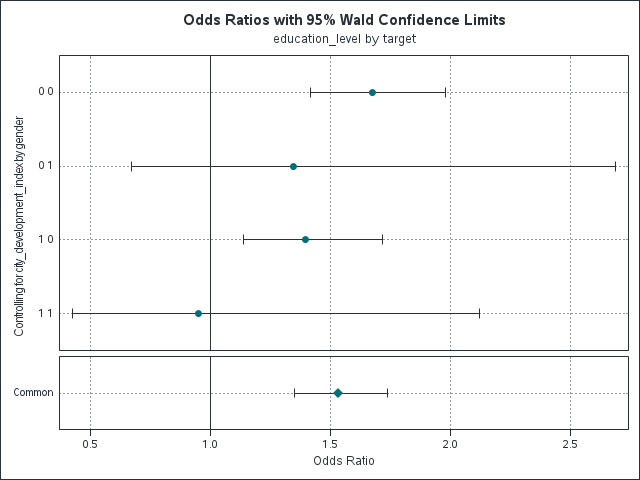

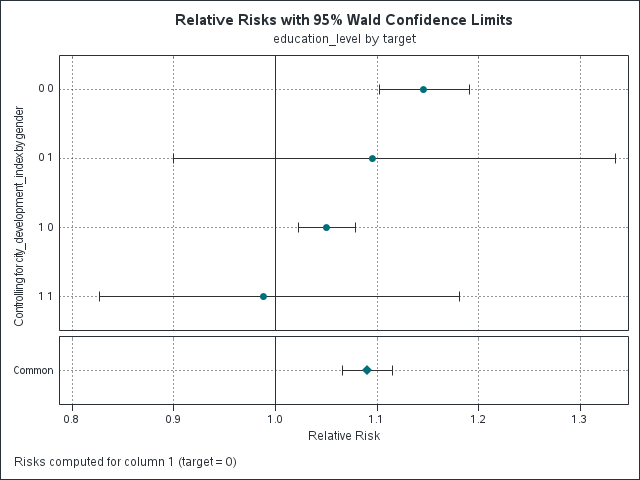

The LOGISTIC Procedure

| Model Information |  |
| --- | --- |
| Data Set | WORK.WORK_DATA |
| Response Variable | target |
| Number of Response Levels | 2 |
| Model | binary logit |
| Optimization Technique | Fisher's scoring |

| Number of Observations Read | 14459 |
| --- | --- |
| Number of Observations Used | 14459 |

| Response Profile Ordered Value | Response Profile target | Response Profile Total Frequency |
| --- | --- | --- |
| 1 | 0 | 11121 |
| 2 | 1 | 3338 |

Probability modeled is target=0.

| Class Level Information Class | Class Level Information Value | Class Level Information Design Variables |
| --- | --- | --- |
| city_development_index | 0 | 1 |
|  | 1 | -1 |
| gender | 0 | 1 |
|  | 1 | -1 |
| education_level | 0 | 1 |
|  | 1 | -1 |

| Model Convergence Status |
| --- |
| Convergence criterion (GCONV=1E-8) satisfied. |

| Deviance and Pearson Goodness-of-Fit Statistics Criterion | Deviance and Pearson Goodness-of-Fit Statistics Value | Deviance and Pearson Goodness-of-Fit Statistics DF | Deviance and Pearson Goodness-of-Fit Statistics Value/DF | Deviance and Pearson Goodness-of-Fit Statistics Pr > ChiSq |
| --- | --- | --- | --- | --- |
| Deviance | 4.6870 | 4 | 1.1717 | 0.3210 |
| Pearson | 4.9042 | 4 | 1.2261 | 0.2973 |

Number of unique profiles: 8

| Model Fit Statistics Criterion | Model Fit Statistics Intercept Only | Model Fit Statistics Intercept and Covariates |
| --- | --- | --- |
| AIC | 15626.772 | 15192.903 |
| SC | 15634.351 | 15223.219 |
| -2 Log L | 15624.772 | 15184.903 |

| R-Square | 0.0300 | Max-rescaled R-Square | 0.0454 |
| --- | --- | --- | --- |

| Testing Global Null Hypothesis: BETA=0 Test | Testing Global Null Hypothesis: BETA=0 Chi-Square | Testing Global Null Hypothesis: BETA=0 DF | Testing Global Null Hypothesis: BETA=0 Pr > ChiSq |
| --- | --- | --- | --- |
| Likelihood Ratio | 439.8690 | 3 | <.0001 |
| Score | 435.5792 | 3 | <.0001 |
| Wald | 423.7058 | 3 | <.0001 |

| Type 3 Analysis of Effects Effect | Type 3 Analysis of Effects DF | Type 3 Analysis of Effects Wald Chi-Square | Type 3 Analysis of Effects Pr > ChiSq |
| --- | --- | --- | --- |
| city_development_ind | 1 | 382.1963 | <.0001 |
| gender | 1 | 10.2969 | 0.0013 |
| education_level | 1 | 44.1815 | <.0001 |

| Analysis of Maximum Likelihood Estimates Parameter | Analysis of Maximum Likelihood Estimates | Analysis of Maximum Likelihood Estimates DF | Analysis of Maximum Likelihood Estimates Estimate | Analysis of Maximum Likelihood Estimates Standard Error | Analysis of Maximum Likelihood Estimates Wald Chi-Square | Analysis of Maximum Likelihood Estimates Pr > ChiSq |
| --- | --- | --- | --- | --- | --- | --- |
| Intercept |  | 1 | 1.2881 | 0.0437 | 869.5967 | <.0001 |
| city_development_ind | 0 | 1 | -0.3962 | 0.0203 | 382.1963 | <.0001 |
| gender | 0 | 1 | 0.1107 | 0.0345 | 10.2969 | 0.0013 |
| education_level | 0 | 1 | 0.2145 | 0.0323 | 44.1815 | <.0001 |

| Odds Ratio Estimates Effect | Odds Ratio Estimates Point Estimate | Odds Ratio Estimates 95% Wald Confidence Limits | Odds Ratio Estimates 95% Wald Confidence Limits |
| --- | --- | --- | --- |
| city_development_ind 0 vs 1 | 0.453 | 0.418 | 0.490 |
| gender 0 vs 1 | 1.248 | 1.090 | 1.429 |
| education_level 0 vs 1 | 1.536 | 1.353 | 1.743 |

| Association of Predicted Probabilities and Observed Responses |  |  |  |
| --- | --- | --- | --- |
| Percent Concordant | 45.4 | Somers' D | 0.221 |
| Percent Discordant | 23.3 | Gamma | 0.321 |
| Percent Tied | 31.3 | Tau-a | 0.078 |
| Pairs | 37121898 | c | 0.610 |

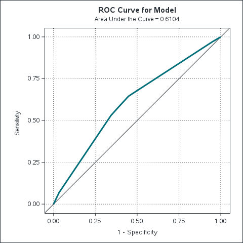

| Partition for the Hosmer and Lemeshow Test Group | Partition for the Hosmer and Lemeshow Test Total | Partition for the Hosmer and Lemeshow Test target = 0 Observed | Partition for the Hosmer and Lemeshow Test target = 0 Expected | Partition for the Hosmer and Lemeshow Test target = 1 Observed | Partition for the Hosmer and Lemeshow Test target = 1 Expected |
| --- | --- | --- | --- | --- | --- |
| 1 | 459 | 302 | 292.83 | 157 | 166.17 |
| 2 | 5293 | 3619 | 3638.56 | 1674 | 1654.44 |
| 3 | 1657 | 1298 | 1293.53 | 359 | 363.47 |
| 4 | 6088 | 5065 | 5048.68 | 1023 | 1039.32 |
| 5 | 962 | 837 | 847.39 | 125 | 114.61 |

| Hosmer and Lemeshow Goodness-of-Fit Test Chi-Square | Hosmer and Lemeshow Goodness-of-Fit Test DF | Hosmer and Lemeshow Goodness-of-Fit Test Pr > ChiSq |
| --- | --- | --- |
| 2.5772 | 3 | 0.4615 |

The GENMOD Procedure

| Model Information |  |
| --- | --- |
| Data Set | WORK.WORK_DATA |
| Distribution | Binomial |
| Link Function | Logit |
| Dependent Variable | target |

| Number of Observations Read | 14459 |
| --- | --- |
| Number of Observations Used | 14459 |
| Number of Events | 11121 |
| Number of Trials | 14459 |

| Class Level Information Class | Class Level Information Levels | Class Level Information Values |
| --- | --- | --- |
| city_development_ind | 2 | 0 1 |
| gender | 2 | 0 1 |
| education_level | 2 | 0 1 |

| Response Profile Ordered Value | Response Profile target | Response Profile Total Frequency |
| --- | --- | --- |
| 1 | 0 | 11121 |
| 2 | 1 | 3338 |

PROC GENMOD is modeling the probability that target='0'. One way to change this to model the probability that target='1' is to specify the DESCENDING option in the PROC statement.

| Criteria For Assessing Goodness Of Fit Criterion | Criteria For Assessing Goodness Of Fit DF | Criteria For Assessing Goodness Of Fit Value | Criteria For Assessing Goodness Of Fit Value/DF |
| --- | --- | --- | --- |
| Log Likelihood |  | -7592.4513 |  |
| Full Log Likelihood |  | -7592.4513 |  |
| AIC (smaller is better) |  | 15192.9026 |  |
| AICC (smaller is better) |  | 15192.9054 |  |
| BIC (smaller is better) |  | 15223.2189 |  |

| Algorithm converged. |
| --- |

| Analysis Of Maximum Likelihood Parameter Estimates Parameter | Analysis Of Maximum Likelihood Parameter Estimates | Analysis Of Maximum Likelihood Parameter Estimates DF | Analysis Of Maximum Likelihood Parameter Estimates Estimate | Analysis Of Maximum Likelihood Parameter Estimates Standard Error | Analysis Of Maximum Likelihood Parameter Estimates Wald 95% Confidence Limits | Analysis Of Maximum Likelihood Parameter Estimates Wald 95% Confidence Limits | Analysis Of Maximum Likelihood Parameter Estimates Wald Chi-Square | Analysis Of Maximum Likelihood Parameter Estimates Pr > ChiSq |
| --- | --- | --- | --- | --- | --- | --- | --- | --- |
| Intercept |  | 1 | 1.3591 | 0.0686 | 1.2247 | 1.4935 | 392.86 | <.0001 |
| city_development_ind | 0 | 1 | -0.7924 | 0.0405 | -0.8719 | -0.7130 | 382.20 | <.0001 |
| city_development_ind | 1 | 0 | 0.0000 | 0.0000 | 0.0000 | 0.0000 | . | . |
| gender | 0 | 1 | 0.2215 | 0.0690 | 0.0862 | 0.3568 | 10.30 | 0.0013 |
| gender | 1 | 0 | 0.0000 | 0.0000 | 0.0000 | 0.0000 | . | . |
| education_level | 0 | 1 | 0.4290 | 0.0645 | 0.3025 | 0.5556 | 44.18 | <.0001 |
| education_level | 1 | 0 | 0.0000 | 0.0000 | 0.0000 | 0.0000 | . | . |
| Scale |  | 0 | 1.0000 | 0.0000 | 1.0000 | 1.0000 |  |  |

Note:The scale parameter was held fixed.

The GENMOD Procedure

| Model Information |  |
| --- | --- |
| Data Set | WORK.WORK_DATA |
| Distribution | Binomial |
| Link Function | Logit |
| Dependent Variable | target |

| Number of Observations Read | 14459 |
| --- | --- |
| Number of Observations Used | 14459 |
| Number of Events | 3338 |
| Number of Trials | 14459 |

| Class Level Information Class | Class Level Information Levels | Class Level Information Values |
| --- | --- | --- |
| city_development_ind | 2 | 0 1 |
| gender | 2 | 0 1 |
| education_level | 2 | 0 1 |

| Response Profile Ordered Value | Response Profile target | Response Profile Total Frequency |
| --- | --- | --- |
| 1 | 1 | 3338 |
| 2 | 0 | 11121 |

PROC GENMOD is modeling the probability that target='1'.

| Criteria For Assessing Goodness Of Fit Criterion | Criteria For Assessing Goodness Of Fit DF | Criteria For Assessing Goodness Of Fit Value | Criteria For Assessing Goodness Of Fit Value/DF |
| --- | --- | --- | --- |
| Log Likelihood |  | -7592.4513 |  |
| Full Log Likelihood |  | -7592.4513 |  |
| AIC (smaller is better) |  | 15192.9026 |  |
| AICC (smaller is better) |  | 15192.9054 |  |
| BIC (smaller is better) |  | 15223.2189 |  |

| Algorithm converged. |
| --- |

| Analysis Of Maximum Likelihood Parameter Estimates Parameter | Analysis Of Maximum Likelihood Parameter Estimates | Analysis Of Maximum Likelihood Parameter Estimates DF | Analysis Of Maximum Likelihood Parameter Estimates Estimate | Analysis Of Maximum Likelihood Parameter Estimates Standard Error | Analysis Of Maximum Likelihood Parameter Estimates Wald 95% Confidence Limits | Analysis Of Maximum Likelihood Parameter Estimates Wald 95% Confidence Limits | Analysis Of Maximum Likelihood Parameter Estimates Wald Chi-Square | Analysis Of Maximum Likelihood Parameter Estimates Pr > ChiSq |
| --- | --- | --- | --- | --- | --- | --- | --- | --- |
| Intercept |  | 1 | -1.3591 | 0.0686 | -1.4935 | -1.2247 | 392.86 | <.0001 |
| city_development_ind | 0 | 1 | 0.7924 | 0.0405 | 0.7130 | 0.8719 | 382.20 | <.0001 |
| city_development_ind | 1 | 0 | 0.0000 | 0.0000 | 0.0000 | 0.0000 | . | . |
| gender | 0 | 1 | -0.2215 | 0.0690 | -0.3568 | -0.0862 | 10.30 | 0.0013 |
| gender | 1 | 0 | 0.0000 | 0.0000 | 0.0000 | 0.0000 | . | . |
| education_level | 0 | 1 | -0.4290 | 0.0645 | -0.5556 | -0.3025 | 44.18 | <.0001 |
| education_level | 1 | 0 | 0.0000 | 0.0000 | 0.0000 | 0.0000 | . | . |
| Scale |  | 0 | 1.0000 | 0.0000 | 1.0000 | 1.0000 |  |  |

Note:The scale parameter was held fixed.